# Investigating Baseball Data: Batting and Pitching

I will investigate the Lahman Baseball Database (available here: http://www.seanlahman.com/baseball-archive/statistics/) to answer the following interesting questions:

- Have batting averages increased or decreased over time?
- Are good pitchers also good batters, in general?

This report uses some rudimentary and informal techniques for comparison of different group of players. Further statistical analysis would be required to answer these questions with rigor.

# Obtain the Data

```python
import urllib.request as request
request.urlretrieve('http://seanlahman.com/files/database/baseballdatabank-master_2016-03-02.zip', "baseballdatabank-master_2016-03-02.zip")

from zipfile import ZipFile
zip = ZipFile('baseballdatabank-master_2016-03-02.zip')
zip.extractall()
```

```
('baseballdatabank-master_2016-03-02.zip',
 <http.client.HTTPMessage at 0x28cca3055f8>)
```

# Load the Batting Data

```python
import pandas as pd
batting_df = pd.read_csv("baseballdatabank-master\core\Batting.csv")
print(batting_df.columns)
print("There are %d batters: " % len(batting_df))
```

```
Index(['playerID', 'yearID', 'stint', 'teamID', 'lgID', 'G', 'AB', 'R', 'H',
       '2B', '3B', 'HR', 'RBI', 'SB', 'CS', 'BB', 'SO', 'IBB', 'HBP', 'SH',
       'SF', 'GIDP'],
      dtype='object')
There are 101332 batters:
```

# Subset data by selecting columns for analysis:

```python
batting_df = batting_df[['playerID', 'yearID', 'AB', 'H']]
batting_df.head(5)
```

|  | playerID | yearID | AB | H |
| --- | --- | --- | --- | --- |
| 0 | abercda01 | 1871 | 4.0 | 0.0 |
| 1 | addybo01 | 1871 | 118.0 | 32.0 |
| 2 | allisar01 | 1871 | 137.0 | 40.0 |
| 3 | allisdo01 | 1871 | 133.0 | 44.0 |
| 4 | ansonca01 | 1871 | 120.0 | 39.0 |

# Add/Modify data

Batting average is defined as the number of hits per "at bat". We'll calculate the batting average, as this is a popular metric for batting skills. We also want to do some time series analysis. Since there quite a few years in the data set, we will bin the data by decade in case that is useful later.

```python
batting_df['average'] = batting_df['H'] / batting_df['AB']
batting_df['decade'] = batting_df.apply(lambda series: int(series['yearID'] / 10), axis="columns")
batting_df.head(5)
```

|  | playerID | yearID | AB | H | average | decade |
| --- | --- | --- | --- | --- | --- | --- |
| 0 | abercda01 | 1871 | 4.0 | 0.0 | 0.000000 | 187 |
| 1 | addybo01 | 1871 | 118.0 | 32.0 | 0.271186 | 187 |
| 2 | allisar01 | 1871 | 137.0 | 40.0 | 0.291971 | 187 |
| 3 | allisdo01 | 1871 | 133.0 | 44.0 | 0.330827 | 187 |
| 4 | ansonca01 | 1871 | 120.0 | 39.0 | 0.325000 | 187 |

# Correct anomalous/missing data

Let's take a look at the distribution of batting averages, to see if there is anything interesting that might affect our analysis:

```python
batting_df['average'].describe()
```

```
C:\Users\Owner\Anaconda3\envs\data_analysis\lib\site-packages\numpy\lib\function_base.py:3834: RuntimeWarning: Invalid value encountered in percentile
  RuntimeWarning)
```

```
count    86410.000000
mean         0.209025
std          0.122313
min          0.000000
25%               NaN
50%               NaN
75%               NaN
max          1.000000
Name: average, dtype: float64
```

Curiously, some batters had a perfect batting average. In addition, we are unable to group the data into percentiles because of missing values, as reflected in the warning above.

```python
perfect_batters = batting_df.loc[batting_df['average']==1.0]
len(perfect_batters)
```

```
448
```

Looking in more depth, we find that they had few at bats:

```python
perfect_batters.head(5)[['playerID', 'AB', 'average']]
```

|  | playerID | AB | average |
| --- | --- | --- | --- |
| 500 | snowch01 | 1.0 | 1.0 |
| 1992 | baldwki01 | 1.0 | 1.0 |
| 4334 | mccafsp01 | 1.0 | 1.0 |
| 5880 | gumbebi01 | 1.0 | 1.0 |
| 5964 | oconnfr01 | 2.0 | 1.0 |

```python
batting_df = batting_df[batting_df['AB'] >= 20]
```

In addition, we will drop missing values and look at the new distribution:

```python
batting_df = batting_df.dropna()
batting_df['average'].describe()
```

```
count    62394.000000
mean         0.234212
std          0.064901
min          0.000000
25%          0.200000
50%          0.245122
75%          0.277778
max          0.517241
Name: average, dtype: float64
```

# Exploratory Analysis: Distribution of Batting Averages

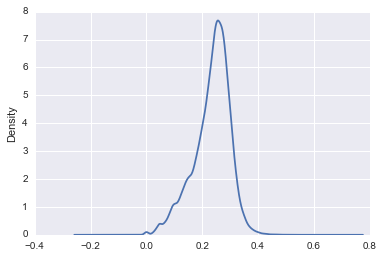

```python
# Plot the distribution
batting_df['average'].plot.kde()
```

# Exploratory Analyis: Batting Average over time

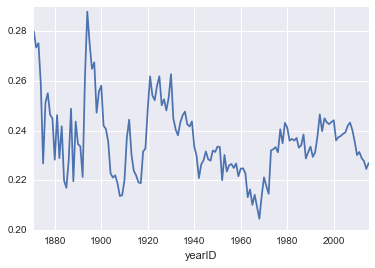

```python
import matplotlib.pyplot as plt
import seaborn
%matplotlib inline
batting_df.groupby('yearID')['average'].mean().plot()
```

There are some interesting changes in batting average over time. There was a spike leading up to the 1890's, followed by a steep decline, then a couple spikes leading up to a peak in the 1920's, followed by a long, slow decline into the 1960's. After that batting averages trended up into the 80's and to year 2000. We might want to explore why this happened using other data in our data set.

# Compare Pitchers Who Bat and Those Who Don't

The "Designated Hitter" rule allows a team to use one non-fielding player as a batter, typically in place of the pitcher. This rule was introduced in 1973 in the American League because pitchers are not typically good at batting. In our data set, Appearances.G_dh has the # of games as designated hitter.

We will divide the pitchers into two groups -- those who have batted, and those who haven't -- and compare those who have batted with the overall population of players. Recall that the batting and pitching data is annual, so each player can appear multiple times in the data. As part of this analysis, we will need to group the annual data on playerID, otherwise there would be multiple entries per player in each set:

```python
# Unique pitchers
pitcher_df = pd.read_csv("baseballdatabank-master\core\Pitching.csv")
pitcher_by_playerID = pitcher_df.groupby('playerID')
print("There are %d pitchers" % len(pitcher_by_playerID))

# Unique batters
batting_by_playerID = batting_df.groupby('playerID')
print("There are %d batters" % len(batting_by_playerID))

# Unique batters who are also pitchers
batting_pitchers_df = pd.merge(pitcher_df, batting_df, on="playerID", how="inner")
print("There are %d batting pitchers." % len(batting_pitchers_df.groupby('playerID')))

# Unique pitchers who are not batters:
non_batting_pitchers_df = pitcher_df[~pitcher_df['playerID'].isin(batting_df['playerID'])]
print("There are %d non-batting pitchers." % len(non_batting_pitchers_df.groupby('playerID')))
```

```
There are 9126 pitchers
There are 11308 batters
There are 3670 batting pitchers.
There are 5456 non-batting pitchers.
```

[output not shown]

## How do batting pitchers perform vs. average?

Again, we look at the mean batting average for all batters and all years:

```python
batting_df['average'].mean()
```

```
0.23421166865757706
```

```python
batting_pitchers_df['average'].mean()
```

```
0.17619840158259503
```

It does appear that pitchers are worse at batting, as they average 0.176 vs. the mean batting average of 0.2342 for all players. It would be interesting to quantify this with a statistical test (t-test?), perhaps in a follow-up report.